# Who survives the sinking of the Titanic?

Today we'll be trying to determine what might make a passenger more or less likely to survive the Titanic.

We'll also try to predict, based on certain features, whether we can predict if a person would survive.

We'll be employing:

- Numpy
- Pandas
- Pyplot from Matplotlib
- Scikit-Learn

```python
# Let's load up some packages that we'll be using throughout:

import numpy as np
import pandas as pd
from mpl_toolkits.mplot3d import Axes3D
from matplotlib import pyplot as plt
```

The first thing we should always do is look at the structure of our dataset.

We want to see how much of our data is numerical, string, null, etc. As well as what types of features we have to work with.

We'll load the data here and take a quick peek at it using `df.head()`

```python
# We use panda's built-in .read_csv() function to read the csv files:

train_df_raw = pd.read_csv('train.csv', header=0)

# And we'll take a quick peek at the first 5 rows using .head():

train_df_raw.head()
```

|  | PassengerId | Survived | Pclass | Name | Sex | Age | SibSp | Parch | Ticket | Fare | Cabin | Embarked |
| --- | --- | --- | --- | --- | --- | --- | --- | --- | --- | --- | --- | --- |
| 0 | 1 | 0 | 3 | Braund, Mr. Owen Harris | male | 22.0 | 1 | 0 | A/5 21171 | 7.2500 | NaN | S |
| 1 | 2 | 1 | 1 | Cumings, Mrs. John Bradley (Florence Briggs Th... | female | 38.0 | 1 | 0 | PC 17599 | 71.2833 | C85 | C |
| 2 | 3 | 1 | 3 | Heikkinen, Miss. Laina | female | 26.0 | 0 | 0 | STON/O2. 3101282 | 7.9250 | NaN | S |
| 3 | 4 | 1 | 1 | Futrelle, Mrs. Jacques Heath (Lily May Peel) | female | 35.0 | 1 | 0 | 113803 | 53.1000 | C123 | S |
| 4 | 5 | 0 | 3 | Allen, Mr. William Henry | male | 35.0 | 0 | 0 | 373450 | 8.0500 | NaN | S |

A lot of the data are categorical. We'll have to convert any non-numerical values to numbers before proceeding with analysis.

Before we do that, we want to see how our data distribute. It's important to know about outliers and biases in the data before you proceed with any analyses.

So first, let's plot some of the data to see what the passenger distributions look like.

```python
# First, we make a list of the columns we want to plot:

cols = ['Pclass', 'Sex', 'Age', 'Fare']

# Then we tell pandas to drop any rows with null values in any of those columns:

df_plot = train_df_raw[cols].dropna(axis=0)
```

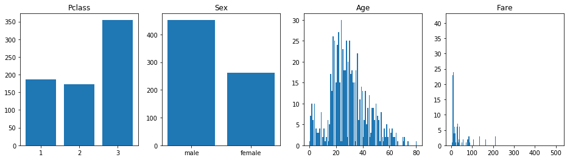

```python
# And now we make our figures:

fig = plt.figure(figsize=[16, 4])

for i in range(len(cols)):

    column_name = cols[i]

    ax = fig.add_subplot(1,4,i+1)
    ax.bar(list(df_plot[column_name].value_counts().index),
           list(df_plot[column_name].value_counts()))

    plt.title(column_name)

plt.show()
```

Already, we can see that there are biases in the data. For instance, there are almsost twice as many men as women. There are also a lot of 3rd class passengers relative to 1st and 2nd class. We won't know how these biases will affect our models until we get started, but it's import to keep them in mind as we proceed.

We can also start to see that there may be outliers in certain features, like in Fare. We'll have to trim those out of the data before we use those features for modeling, as they clearly don't represent the majority of passengers.

```python
# First we get rid of null values for any columns we're interested in studying further:

train_df = train_df_raw.dropna(axis=0, subset=['Sex', 'Embarked', 'Fare', 'Age'])
```

```python
# To generate a list of features found in a column, use .unique() or .value_counts()

print(train_df.Sex.unique())

print(train_df.Embarked.unique())
```

```
['male' 'female']
['S' 'C' 'Q']
```

```python
# Now we make lists of the values found in those columns:

sexes = ['male', 'female']

embarked = ['S', 'C', 'Q']

# Here, we create 2 new feature columns. One that codifies Sex and one that codifies Embarked:

train_df['Sex_code'] = train_df.Sex.apply(lambda x: sexes.index(x))

train_df['Embarked_code'] = train_df.Embarked.apply(lambda x: embarked.index(x))
```

```python
# Here, we remove the upper outliers of the Fare column by setting an upper limit:

train_df = train_df[train_df.Fare < 200]
```

```python
# Now we can check for overt correlations for our df:

train_df.corr()
```

|  | PassengerId | Survived | Pclass | Age | SibSp | Parch | Fare | Sex_code | Embarked_code |
| --- | --- | --- | --- | --- | --- | --- | --- | --- | --- |
| PassengerId | 1.000000 | 0.018497 | -0.034074 | 0.031964 | -0.071769 | -0.002500 | -0.004046 | -0.031654 | -0.017434 |
| Survived | 0.018497 | 1.000000 | -0.342685 | -0.084907 | -0.021044 | 0.097305 | 0.294836 | 0.526294 | 0.096049 |
| Pclass | -0.034074 | -0.342685 | 1.000000 | -0.376287 | 0.082515 | 0.060230 | -0.674084 | -0.132694 | -0.086622 |
| Age | 0.031964 | -0.084907 | -0.376287 | 1.000000 | -0.306414 | -0.201969 | 0.132137 | -0.099819 | 0.010413 |
| SibSp | -0.071769 | -0.021044 | 0.082515 | -0.306414 | 1.000000 | 0.372488 | 0.195578 | 0.101479 | 0.010519 |
| Parch | -0.002500 | 0.097305 | 0.060230 | -0.201969 | 0.372488 | 1.000000 | 0.209745 | 0.257800 | -0.017778 |
| Fare | -0.004046 | 0.294836 | -0.674084 | 0.132137 | 0.195578 | 0.209745 | 1.000000 | 0.218347 | 0.140964 |
| Sex_code | -0.031654 | 0.526294 | -0.132694 | -0.099819 | 0.101479 | 0.257800 | 0.218347 | 1.000000 | 0.091149 |
| Embarked_code | -0.017434 | 0.096049 | -0.086622 | 0.010413 | 0.010519 | -0.017778 | 0.140964 | 0.091149 | 1.000000 |

We can already see some interesting categories correlating with `Survived`. We have a correlation with passenger class and money paid for fare. We also have a correlation with sex...

What about the "women and children first" adage? Could we use `Age` and `Sex` to determine if someone will survive?

We'll throw in `Fare` (since we know that life's a bitch unless you're rich).

Let's create a K Nearest Neighbors classifier that uses these features to predict survival.

## K Nearest Neighbors

This classifier is pretty cool.

It essentially relies on the idea that points in an Nth-dimensional space that fall closest to your point of interest will most likely predict the class for that point.

The K refers to how many neighbors' classes you want to assess to make your classification.

Because this classifier uses euclidean distance to determine proximity to your point of interest, it's important that all axes/features be normalized to the same scale.

If you have a feature on a scale that is many orders of magnitude larger than another dimension, the distances will be unreasonably high in that axis. Normalizing so that all feature axes are on a 0.0-to-1.0 scale eliminates this completely.

So for a k of 3, the data might look like this:

[figure not shown]

You can optionally weight the class instances for the neighbors by dividing the class by the distance (with the idea that the nearer a neighbor is, the more likely your point is to be similar to it in class).

K can be adjusted as needed, but should generally be odd (so as to never have ties for class).

## For classifiers: Accuracy, Precision, and Recall

One of the most important ways of telling whether your classifiers are doing a good job is to measure accuracy, precision, and recall. These essentially tell us how well your classifier predicted class A when class A was supposed to be predicted and never else.

Note:

$TP$ = True Positive, $TN$ = True Negative, $FP$ = False Positive, $FN$ = False Negative

### Accuracy

Accuracy can be thought of as being the proportion of times your classifier correctly classified a sample. The equation is as follows:

##### $Accuracy = \frac{TP + TN}{TP + FP + TN + FN}$

This alone doesn't give you a sense of what the $FP$ is. It's possible that in order to classify $TP$ correctly, you your classifier is being a little too generous, and you'll have a high $FP$ rate because of it.

### Precision

Precision starts getting more specific. Precision says, of all the times your classifier predicted a positive, how often was it right? The equation looks like this:

##### $Precision = \frac{TP}{TP + FP}$

This still isn't enough to get a sense of whether your classifier is doing a good job, though, because it's possible your classifier is too conservative, and almost never predicts a positive unless it's at an absolute extreme. You may have a very high $FN$ rate here you that don't see

[figure not shown]

### Recall

Recall breaks this problem down a little bit more. Recall asks: of all the positives in the dataset, how many did the classifier actually get? The equation looks like this:

###### $Recall = \frac{TP}{TP + FN}$

[figure not shown]

The two of these together give you a sense of how well your classifier is doing. So we'll be looking at both.

```python
# First, we'll load the packages we'll need for our classifier.
# A scaler for scaling each feature column,
# a data splitter for generating training and test sets,
# the classifier itself, and the scorers:

from sklearn.preprocessing import MinMaxScaler
from sklearn.model_selection import train_test_split
from sklearn.neighbors import KNeighborsClassifier
from sklearn.metrics import precision_score, recall_score
```

```python
# First, we need to choose the features we're interested in looking at:

features = ['Age', 'Sex_code', 'Fare']

# Now we're going to scale them:

scaler = MinMaxScaler()

# I'm going to fit the scaler to all the values found in our training dataset:

KN_features = pd.DataFrame(scaler.fit_transform(train_df[features]),
                           columns=features)
```

```python
# Now, we're going to split training df into training and test sets:

output = train_test_split(KN_features, train_df['Survived'],
                          test_size=0.2, random_state=7)

train_data, test_data, train_labels, test_labels = output
```

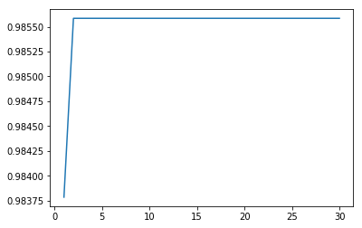

```
2
```

```python
# Since we'll be running K Nearest Neighbors, we should determine the optimal k:

scores = []

for k in range(1, 31):

    classifier = KNeighborsClassifier(n_neighbors=k, weights='distance')
    classifier.fit(train_data, train_labels)

    scores.append(classifier.score(train_data, train_labels))

plt.plot(range(1, 31), scores)
plt.show()
print(scores.index(max(scores)) + 1)
```

```python
# Using the suggested k from above, we make our actual classifier:

classifier = KNeighborsClassifier(n_neighbors=3, weights='distance')
classifier.fit(train_data, train_labels)

# And we see how well it does on our training and test data:

print('Precision Score: ' + str(precision_score(test_labels,
                                         classifier.predict(test_data)))[:5])
print('Recall Score: ' + str(recall_score(test_labels,
                                          classifier.predict(test_data)))[:5])
```

```
Precision Score: 0.6
Recall Score: 0.574
```

That's not too bad. We're getting there.

Let's visualize how our classifier did:

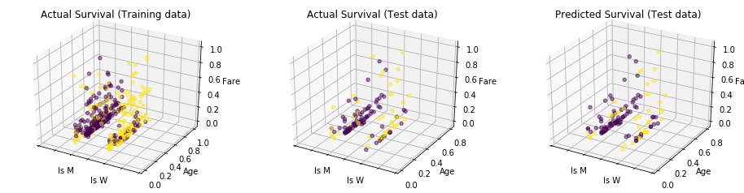

```python
# To visualize the dataset that we trained our model on:

datasets = [train_data, test_data, test_data]
labelsets = [train_labels, test_labels, classifier.predict(test_data)]
titles = ['Actual Survival (Training data)', 'Actual Survival (Test data)',
          'Predicted Survival (Test data)']

fig = plt.figure(figsize=[16, 4])

for i in range(3):

    ax = fig.add_subplot(131+i, projection='3d')
    ax.scatter(datasets[i]['Sex_code'], datasets[i]['Age'], datasets[i]['Fare'],
               alpha=0.5, c=labelsets[i])
    ax.set_xlim((-1.0, 2.0))
    ax.set_xticklabels(['', '', 'Is M', '', 'Is W', '', ''])
    ax.set_ylabel('Age')
    ax.set_zlabel('Fare')
    ax.set_title(titles[i])

plt.show()
```

But I want it to do even better. So we'll get a little more creative and more specific with our features.

I'll generate a feature cross using `Age` and `Sex` to divide people up into two categories:

- Is not woman or child (aka. Is man)
- Is woman or child

```python
train_df['Is_woman_or_child'] = train_df.apply(lambda row: 1 if row.Sex_code == 1
                                               or row.Age <= 10 else 0, axis=1)
```

```python
# First, we need to choose the features we're interested in looking at:

features = ['Is_woman_or_child', 'Fare']

# Now we're going to scale them:

scaler = MinMaxScaler()

# I'm going to fit the scaler to all the values found in our training and test datasets:

KN_features = pd.DataFrame(scaler.fit_transform(train_df[features]),
                           columns=features)
```

```python
# Now, we're going to split training df into training and test sets:

output = train_test_split(KN_features, train_df['Survived'],
                          test_size=0.2, random_state=7)

train_data, test_data, train_labels, test_labels = output
```

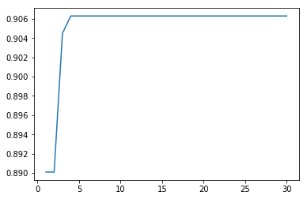

```
4
```

```python
# Since we'll be running K Nearest Neighbors, we should determine the optimal k:

scores = []

for k in range(1, 31):

    classifier = KNeighborsClassifier(n_neighbors=k, weights='distance')
    classifier.fit(train_data, train_labels)

    scores.append(classifier.score(train_data, train_labels))

plt.plot(range(1, 31), scores)
plt.show()
print(scores.index(max(scores)) + 1)
```

```python
# Using the suggested k from above, we make our actual classifier:

classifier = KNeighborsClassifier(n_neighbors=5, weights='distance')
classifier.fit(train_data, train_labels)

# And we see how well it does on our training and test data:

print('Precision Score: ' + str(precision_score(test_labels,
                                         classifier.predict(test_data)))[:5])
print('Recall Score: ' + str(recall_score(test_labels,
                                          classifier.predict(test_data)))[:5])
```

```
Precision Score: 0.745
Recall Score: 0.808
```

This model does considerably better! Sometimes, there's more information in a feature cross than there are in two features independently.

Let's visualize how our model did using matplotlib again

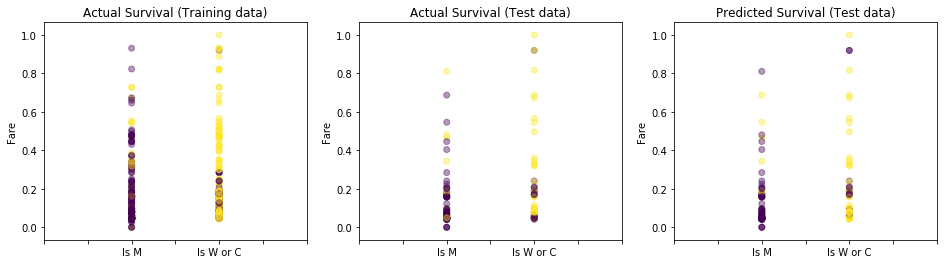

```python
# To visualize the dataset that we trained our model on:

datasets = [train_data, test_data, test_data]
labelsets = [train_labels, test_labels, classifier.predict(test_data)]
titles = ['Actual Survival (Training data)', 'Actual Survival (Test data)',
          'Predicted Survival (Test data)']

fig = plt.figure(figsize=[16, 4])

for i in range(3):

    ax = fig.add_subplot(1, 3, i+1)
    ax.scatter(datasets[i]['Is_woman_or_child'], datasets[i]['Fare'],
               c=labelsets[i], alpha=0.4)
    ax.set_xlim((-1.0, 2.0))
    ax.set_xticklabels(['', '', 'Is M', '', 'Is W or C', '', ''])
    ax.set_title(titles[i])
    ax.set_ylabel('Fare')

plt.show()
```

Feature crosses and codifications are essential to generating models. The data may not always have the best predictive features overtly displayed in its data structure, so you have to get creative in how you approach what to feed into the models

Thanks! Questions?